# CTS

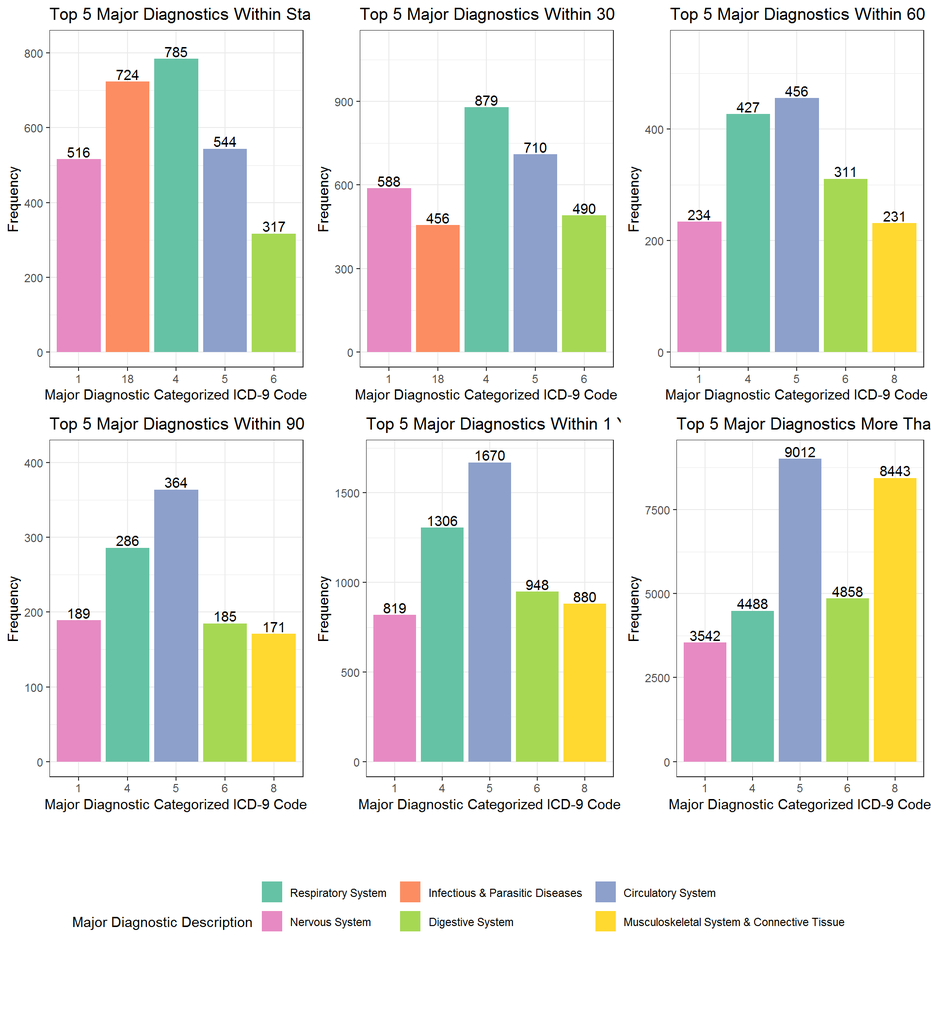

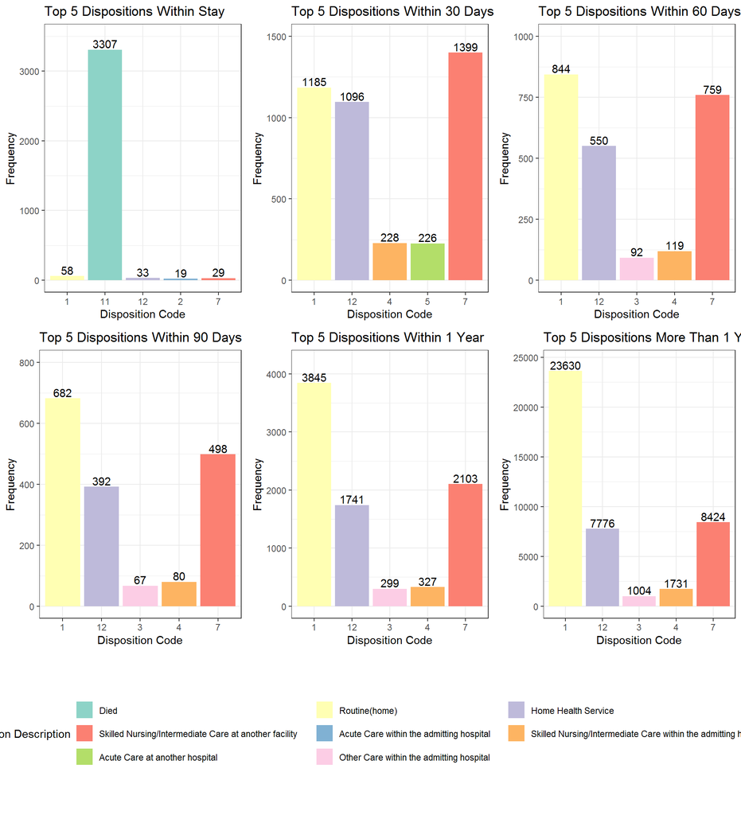

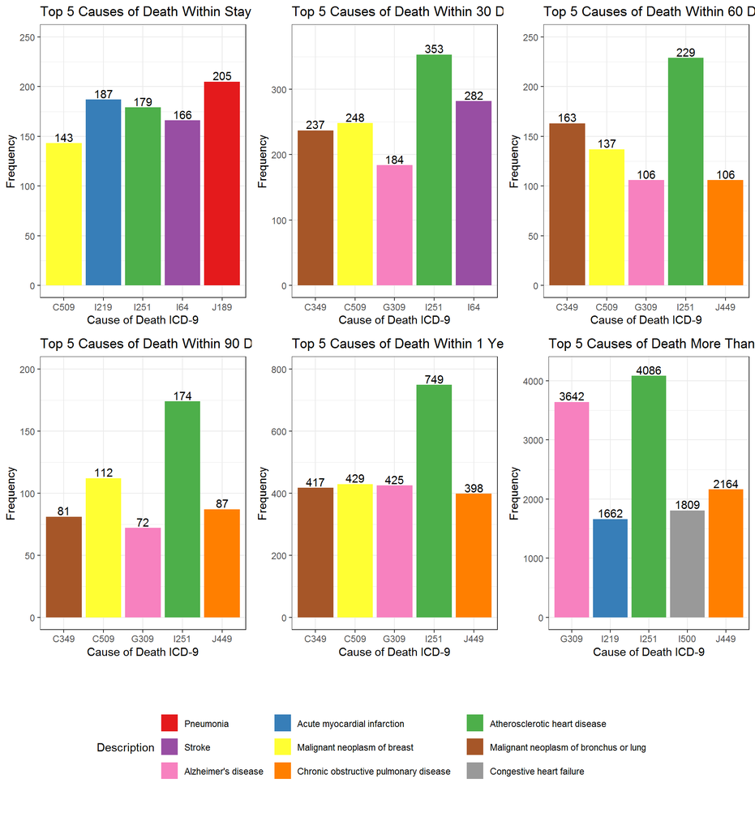

## Basic Logistic Regression

We use elementary logistic regression to test performance for each death outcome dichotomous against another, as a yes no response for our binary model. Testing each outcome giving us 6 logistic regression models, our outcome of interest vs other. For machine learning purposes we split our data of selected covariates we believe would contribute the most to our model for new admit patients and those during their stay, using 70% for training data and 30% for testing data. We use this 70-30 split to train our model with itself of our selected covariates to gauge our models performance and to allow our model to “learn” so that we may test newcoming data with its reserved 30% test data set. From the test data set we are able to gather our models true performance in how it might do to other data sets with the same covariates measured. We use performance metrics such as Area Under Curve (AUC) as diagnostic for our model as it discriminant varies between sensitivity and specificity. Sensitivity is the probability our of model to correctly classify a true positive case, meaning to correctly predict our outcome of interest the death intervals and specificity is the probability to correctly classify a non-positive case that a patient would not die in our intervals after discharge. We value the AUC for overall predictive performance and Sensitivity as we are trying to correctly classify patients who are at risk of dying after their discharge date.

### Within Stay Logistic

Table 1: Within Stay Logistic

| Variable | Description | OR | P-value |
| --- | --- | --- | --- |
| meno_stattype8 | Postemnopausal Other | 9.04 | 0.0332 |
| hbpmed_totyrsH | Regular user but unknown duration | 19.92 | 0.0123 |
| aceinhb_dailyY |  | 2.98 | 0.0242 |
| patient_disposition_cde2 | Acute care within admit hospital | 57.52 | 0.0000 |
| patient_disposition_cde5 | Acute care at another hospital | 6.56 | 0.0040 |
| patient_disposition_cde13 | Other | 56.36 | 0.0000 |

From the Receiver Operator Curve (ROC) we are given the entire distribution of sensitivity and specificity and from this we are able to calculate the area underneath the curve (AUC) for the overall test probabilistic performance. From our logistic regression of deaths within stay vs other we have a AUC score of 0.6080 which is a moderately rated prediction model.

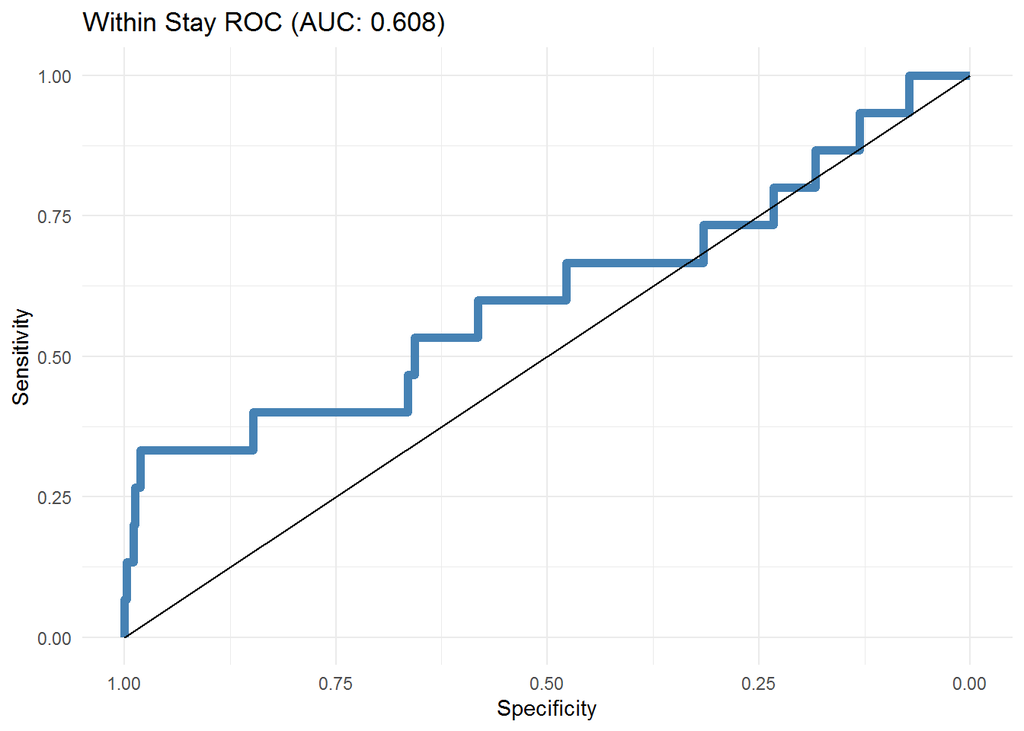

Further exploring our model we are able to find the optimal cutoff point that gives us the optimal sensitivity and specificity in our model that is closest to the AUC score. We obtain an optimal cutoff point of $C = -3.4908$ and in tabular form gives us a sensitivty of 0.3333 and a specificity of 0.9816.

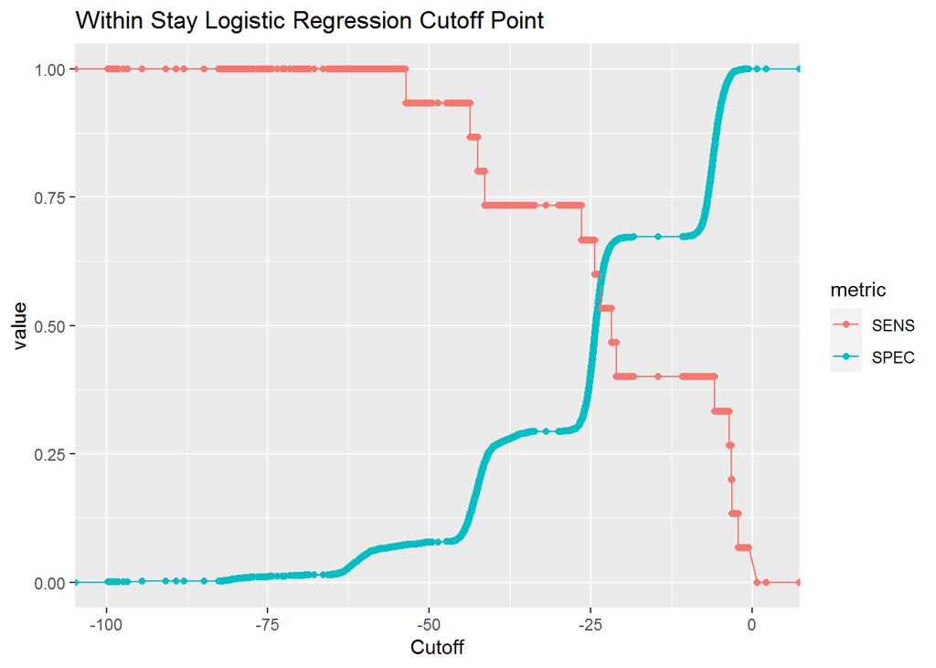

Within Stay Optimal Cutoff Points

| Cutoff | SENS | SPEC | SUM |
| --- | --- | --- | --- |
| -3.4908 | 0.3333 | 0.9816 | 1.3149 |
| -3.4951 | 0.3333 | 0.9814 | 1.3147 |
| -3.4980 | 0.3333 | 0.9813 | 1.3146 |
| -3.5016 | 0.3333 | 0.9811 | 1.3144 |
| -3.5092 | 0.3333 | 0.9810 | 1.3143 |

Sequentially moving to the next category of our death outcome, those that have died within 30 days of their discharge date we find that while holding all other covariates constant those given acute care within their hospital are 11 times as likely to die. We observe the same effect when a patient is admitted to the hospital and is diagnosed in a major category of Hepatobiliary System & Pancreas, Diseases & Disorders are 7.39 times as likely to die within 30 days after discharge.

### Within 30 Days Logistic

Within 30 Days Logistic

| Variable | Description | OR | P-value |
| --- | --- | --- | --- |
| length_of_stay_day_cnt |  | 1.01 | 0.0000 |
| bmi_q1 |  | 0.98 | 0.0055 |
| hbpmed_totyrsE | 3-4 Years | 0.63 | 0.0355 |
| hbpmed_totyrsG | Over 10 Years | 1.29 | 0.0223 |
| sleep_hrsH | Daily ACE Inhibitor over 2 Months | 0.32 | 0.0410 |
| patient_disposition_cde2 | Acute Care within the admit hospital | 11.00 | 0.0000 |
| patient_disposition_cde3 | Other Care within the admit hospital | 1.90 | 0.0030 |
| patient_disposition_cde4 | Skilled Nursing/Intermediate Care within the admitting hospital | 2.79 | 0.0000 |
| patient_disposition_cde5 | Acute Care at another hospital | 3.85 | 0.0000 |
| patient_disposition_cde6 | Other Care at another hospital | 2.48 | 0.0000 |
| patient_disposition_cde7 | Skilled Nursing/Intermediate Care at another facility | 2.83 | 0.0000 |
| patient_disposition_cde10 | Left Against Medical Advice | 8.40 | 0.0023 |
| patient_disposition_cde12 | Home Health Service | 2.62 | 0.0000 |
| patient_disposition_cde13 | Other | 12.72 | 0.0000 |
| major_diag_cat_cde2 | Ear, Nose, Mouth, & Throat, Diseases & Disorders | 6.92 | 0.0280 |
| major_diag_cat_cde4 | Respiratory System, Diseases & Disorders | 3.22 | 0.0000 |
| major_diag_cat_cde6 | Digestive System, Diseases & Disorders | 2.40 | 0.0020 |
| major_diag_cat_cde7 | Hepatobiliary System & Pancreas, Diseases & Disorders | 7.39 | 0.0000 |
| major_diag_cat_cde10 | Endocrine, Nutritional, and Metabolic, Diseases & Disorders | 3.25 | 0.0003 |
| major_diag_cat_cde11 | Kidney and Urinary Tract, Diseases & Disorders | 3.20 | 0.0002 |
| major_diag_cat_cde17 | Myeloproliferative Diseases & Poorly Differentiated Neoplasms | 2.59 | 0.0021 |
| diag1108 | Pneumonia | 1.86 | 0.0330 |
| diag1109 | Biliary tract disease | 2.14 | 0.0113 |
| diag1149 | Osteoarthritis | 0.33 | 0.0131 |
| diag12 | Fracture of neck of femur (hip) | 2.51 | 0.0304 |
| diag1203 | Secondary malignancies | 0.12 | 0.0049 |
| diag142 | Respiratory intubation and mechanical ventilation | 2.46 | 0.0001 |
| proc1216 | Blood transfusion | 2.44 | 0.0049 |
| proc1222 | Other vascular catheterization, not heart | 3.16 | 0.0001 |
| proc154 | Colorectal resection | 2.38 | 0.0059 |
| proc178 |  | 0.36 | 0.0421 |

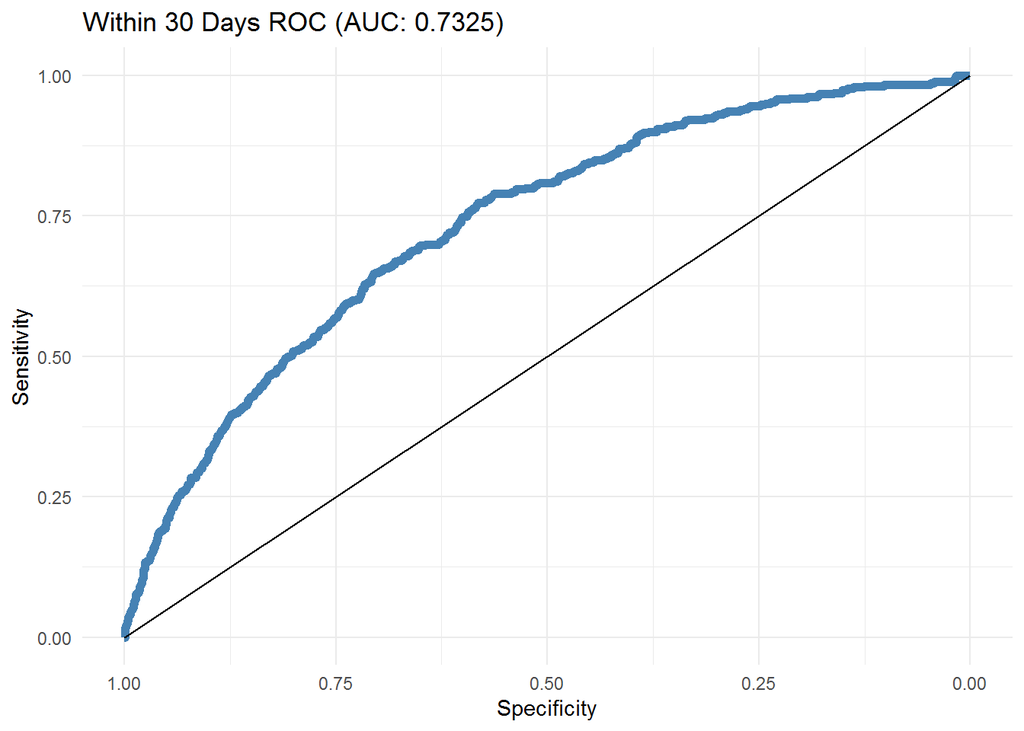

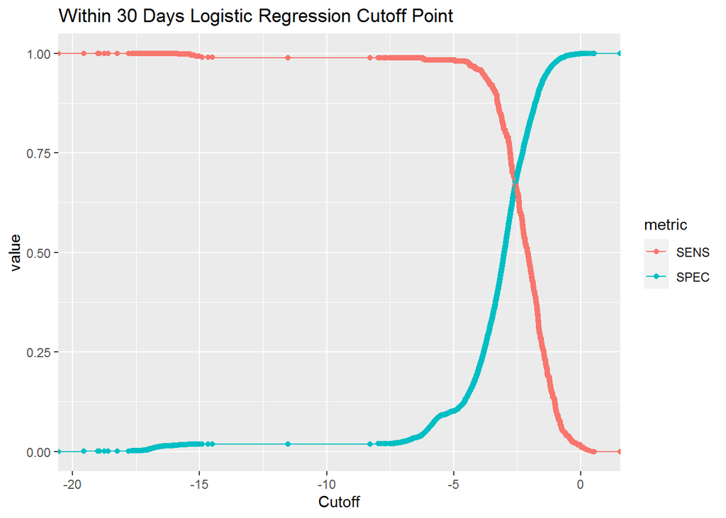

Within 30 Optimal Cutoff Points

| Cutoff | SENS | SPEC | SUM |
| --- | --- | --- | --- |
| -2.8071 | 0.7733 | 0.5824 | 1.3557 |
| -2.8071 | 0.7733 | 0.5822 | 1.3555 |
| -2.8072 | 0.7733 | 0.5820 | 1.3553 |
| -2.8075 | 0.7733 | 0.5819 | 1.3552 |
| -2.8080 | 0.7733 | 0.5817 | 1.3550 |

In our logistic regression model for deaths within 60 days after discharge we observe that when controlling for all other variables every day increase in length of stay patients are 1.01 as likely to die. With the test AUC score of 0.6642 is moderate performing with a cutoff value of $C = -3.2717$ giving us a sensitivity of 0.6556 and a specificity of 0.6013.

### Within 60 Days Logistic

Within 60 Days Logistic

| Variable | OR | P-value |
| --- | --- | --- |
| length_of_stay_day_cnt | 1.01 | 0.0041 |
| preg_ever_q1Yes | 0.73 | 0.0257 |
| preg_total_q1 | 1.07 | 0.0321 |
| meno_stattype8 | 0.37 | 0.0026 |
| meno_stattype11 | 0.46 | 0.0391 |
| hbpmed_totyrsB | 1.65 | 0.0479 |
| patient_disposition_cde2 | 3.52 | 0.0115 |
| patient_disposition_cde3 | 2.04 | 0.0057 |
| patient_disposition_cde4 | 1.72 | 0.0189 |
| patient_disposition_cde5 | 1.79 | 0.0348 |
| patient_disposition_cde6 | 2.40 | 0.0004 |
| patient_disposition_cde7 | 2.45 | 0.0000 |
| patient_disposition_cde8 | 2.17 | 0.0241 |
| patient_disposition_cde12 | 1.56 | 0.0004 |
| diag1108 | 2.27 | 0.0326 |
| diag1226 | 2.63 | 0.0461 |
| diag142 | 2.76 | 0.0006 |
| proc1146 | 0.21 | 0.0040 |
| proc1153 | 0.26 | 0.0088 |
| proc178 | 0.21 | 0.0075 |

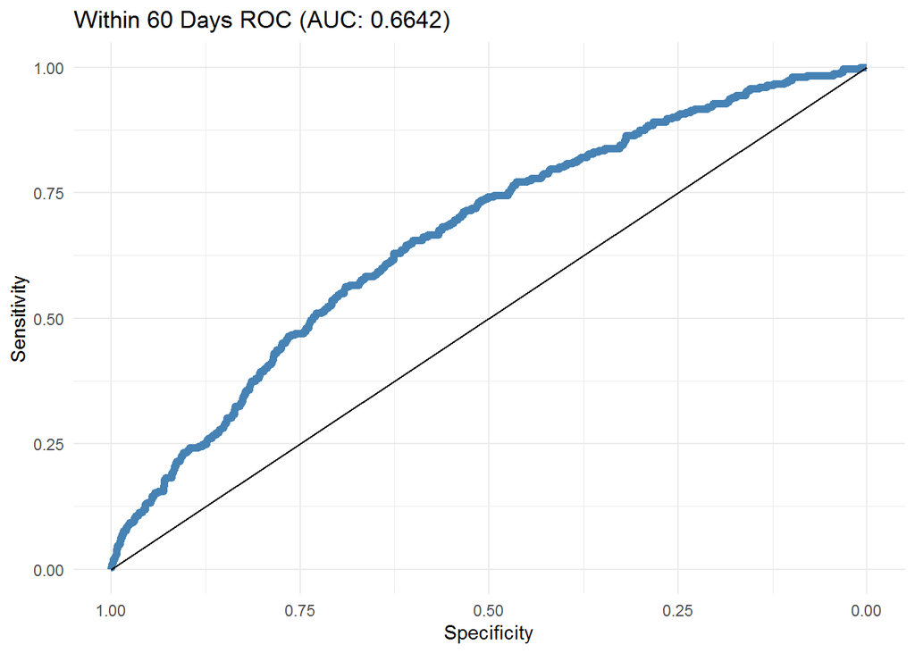

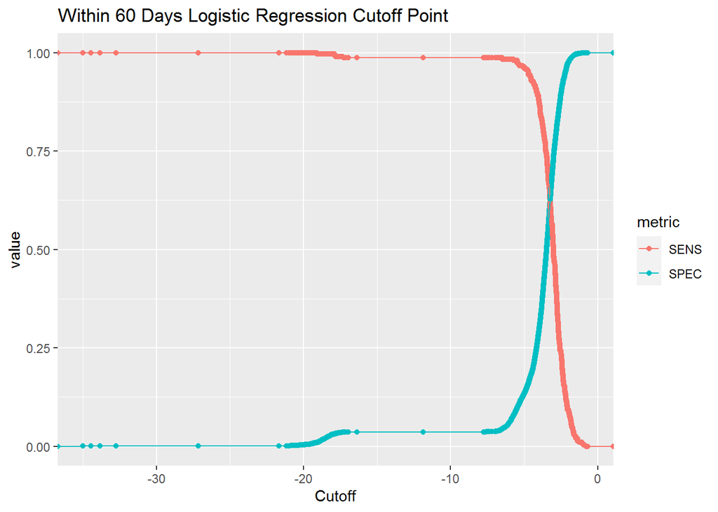

Within 60 Optimal Cutoff Points

| Cutoff | SENS | SPEC | SUM |
| --- | --- | --- | --- |
| -3.2717 | 0.6556 | 0.6013 | 1.2569 |
| -3.2719 | 0.6556 | 0.6011 | 1.2567 |
| -3.2724 | 0.6556 | 0.6010 | 1.2566 |
| -3.2728 | 0.6556 | 0.6008 | 1.2564 |
| -3.2734 | 0.6556 | 0.6007 | 1.2563 |

Within our 90 days logistic model we obtained a AUC score of 0.6664. This gives us moderate predictive performance which we are able to conclude that patients recommended a disposition of acute care within the admitting hospital are 3.01 times as likely to die within 90 days. We obtain an optimal cutoff point of $C = -3.6753$ with a sensitivity of 0.8077 and a specificity of 0.4623.

### Within 90 Days Logistic

Within 90 Days Logistic

| Variable | OR | P-value |
| --- | --- | --- |
| patient_disposition_cde2 | 3.01 | 0.0265 |
| patient_disposition_cde3 | 1.80 | 0.0409 |
| patient_disposition_cde4 | 1.96 | 0.0039 |
| patient_disposition_cde5 | 2.04 | 0.0078 |
| patient_disposition_cde7 | 1.85 | 0.0000 |
| patient_disposition_cde12 | 1.46 | 0.0052 |
| major_diag_cat_cde7 | 3.19 | 0.0087 |
| major_diag_cat_cde17 | 3.24 | 0.0043 |
| diag1108 | 2.74 | 0.0148 |
| proc1152 | 0.09 | 0.0413 |
| proc178 | 0.29 | 0.0384 |
| proc184 | 0.19 | 0.0256 |

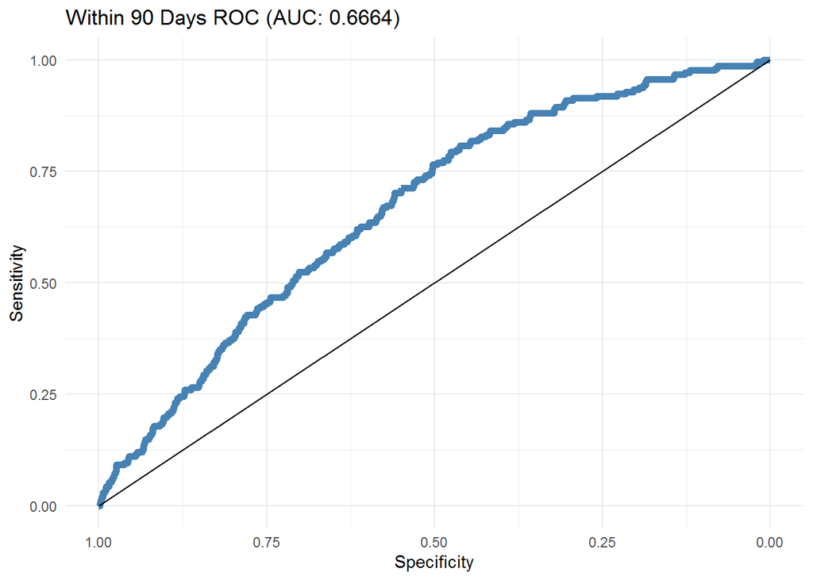

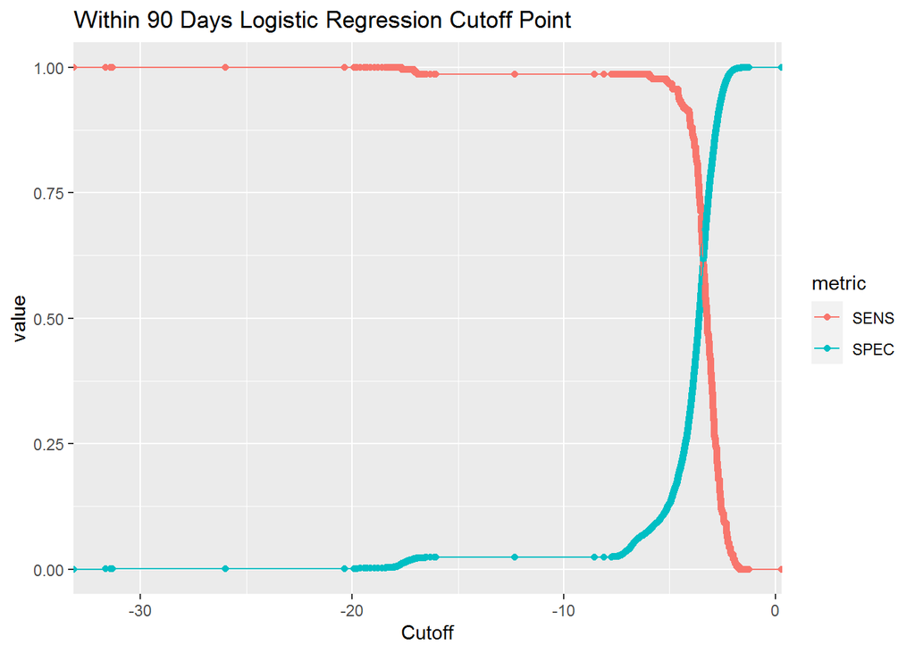

Within 90 Optimal Cutoff Points

| Cutoff | SENS | SPEC | SUM |
| --- | --- | --- | --- |
| -3.6753 | 0.8077 | 0.4623 | 1.2700 |
| -3.6757 | 0.8077 | 0.4621 | 1.2698 |
| -3.6761 | 0.8077 | 0.4620 | 1.2697 |
| -3.6762 | 0.8077 | 0.4618 | 1.2695 |
| -3.6764 | 0.8077 | 0.4616 | 1.2693 |

In observing deaths within 1 year after a patients hospitalization we find that if a pateint were to ever take any oral contraceptives they are 1.06 times as likely to die when controlling for the other covariates. Predictive performance is moderate with an AUC score of 0.6652, allowing us to obtain a cutoff point of $C = -1.8670$, sensitivity of 0.6837 and a specificity of 0.5626.

### Within 1 Year Logistic

Within 1 Year Days Logistic

| Variable | OR | P-value |
| --- | --- | --- |
| oralcntr_ever_q1 | 1.06 | 0.0314 |
| preg_ever_q1Yes | 0.81 | 0.0087 |
| meno_stattype5 | 0.63 | 0.0000 |
| meno_stattype6 | 0.62 | 0.0000 |
| meno_stattype8 | 0.59 | 0.0010 |
| meno_stattype10 | 0.61 | 0.0000 |
| meno_stattype11 | 0.60 | 0.0064 |
| cholmed_dailyY | 0.87 | 0.0380 |
| patient_disposition_cde3 | 2.31 | 0.0000 |
| patient_disposition_cde6 | 1.70 | 0.0004 |
| patient_disposition_cde7 | 1.55 | 0.0000 |
| patient_disposition_cde8 | 1.70 | 0.0082 |
| patient_disposition_cde12 | 1.16 | 0.0371 |
| major_diag_cat_cde1 | 1.65 | 0.0093 |
| major_diag_cat_cde3 | 1.88 | 0.0386 |
| major_diag_cat_cde4 | 1.96 | 0.0003 |
| major_diag_cat_cde7 | 1.93 | 0.0034 |
| major_diag_cat_cde11 | 1.61 | 0.0247 |
| major_diag_cat_cde16 | 1.73 | 0.0125 |
| major_diag_cat_cde17 | 3.13 | 0.0000 |
| major_diag_cat_cde18 | 2.09 | 0.0128 |
| diag1101 | 0.50 | 0.0218 |
| diag1108 | 1.74 | 0.0071 |
| diag1203 | 0.18 | 0.0000 |
| diag1226 | 1.62 | 0.0443 |
| diag1237 | 1.59 | 0.0155 |
| diag142 | 1.47 | 0.0239 |
| proc1222 | 1.70 | 0.0034 |
| proc148 | 0.53 | 0.0288 |
| proc184 | 0.42 | 0.0240 |

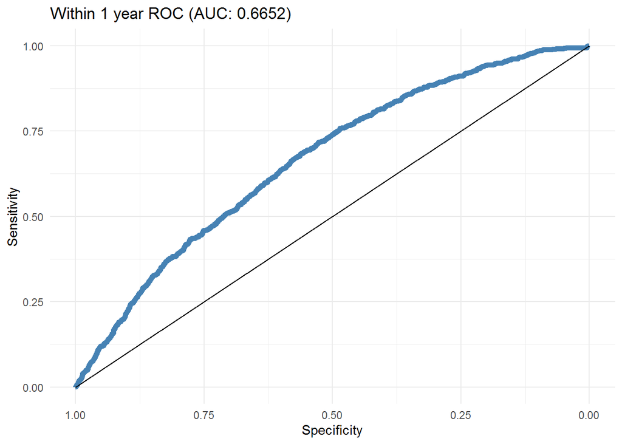

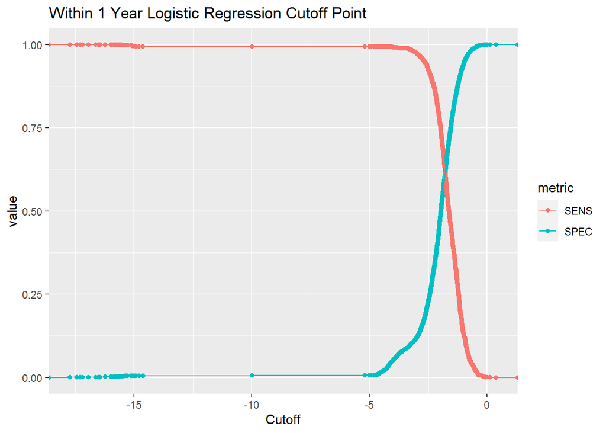

Within 1 Year Optimal Cutoff Points

| Cutoff | SENS | SPEC | SUM |
| --- | --- | --- | --- |
| -1.8670 | 0.6837 | 0.5626 | 1.2463 |
| -1.8674 | 0.6837 | 0.5624 | 1.2461 |
| -1.8680 | 0.6837 | 0.5622 | 1.2459 |
| -1.8686 | 0.6837 | 0.5620 | 1.2457 |
| -1.8689 | 0.6837 | 0.5619 | 1.2456 |

Our logistic model for death interval of more than 1 year after discharge date has the higher prediction performance of an AUC score of 0.7384. Interestingly, if a patient were to ever to be pregnant their odds of dying would be 1.18 times as likely when controlling for all other covariates. We have a cutoff value of $C = 0.9288$ which gives us the optimal sensitivity of 0.6674 and a specificity of 0.6969.

### More Than 1 Year Logistic

More Than 1 Year Logistic

| Variable | OR | P-value |
| --- | --- | --- |
| length_of_stay_day_cnt | 0.98 | 0.0000 |
| preg_ever_q1Yes | 1.18 | 0.0114 |
| meno_stattype5 | 1.38 | 0.0002 |
| meno_stattype6 | 1.41 | 0.0004 |
| meno_stattype8 | 1.53 | 0.0010 |
| meno_stattype9 | 11.28 | 0.0010 |
| meno_stattype10 | 1.60 | 0.0000 |
| meno_stattype11 | 1.49 | 0.0083 |
| bmi_q1 | 1.01 | 0.0157 |
| cholmed_dailyY | 1.20 | 0.0005 |
| patient_disposition_cde2 | 0.14 | 0.0000 |
| patient_disposition_cde3 | 0.39 | 0.0000 |
| patient_disposition_cde4 | 0.57 | 0.0000 |
| patient_disposition_cde5 | 0.36 | 0.0000 |
| patient_disposition_cde6 | 0.40 | 0.0000 |
| patient_disposition_cde7 | 0.42 | 0.0000 |
| patient_disposition_cde8 | 0.56 | 0.0008 |
| patient_disposition_cde12 | 0.58 | 0.0000 |
| patient_disposition_cde13 | 0.13 | 0.0000 |
| major_diag_cat_cde1 | 0.64 | 0.0035 |
| major_diag_cat_cde3 | 0.55 | 0.0180 |
| major_diag_cat_cde4 | 0.39 | 0.0000 |
| major_diag_cat_cde6 | 0.65 | 0.0022 |
| major_diag_cat_cde7 | 0.24 | 0.0000 |
| major_diag_cat_cde10 | 0.60 | 0.0044 |
| major_diag_cat_cde11 | 0.45 | 0.0000 |
| major_diag_cat_cde16 | 0.53 | 0.0003 |
| major_diag_cat_cde17 | 0.30 | 0.0000 |
| major_diag_cat_cde18 | 0.53 | 0.0076 |
| major_diag_cat_cde23 | 0.56 | 0.0202 |
| diag1101 | 2.39 | 0.0005 |
| diag1108 | 0.41 | 0.0000 |
| diag1203 | 4.63 | 0.0000 |
| diag1226 | 0.48 | 0.0002 |
| diag1237 | 0.68 | 0.0189 |
| diag1254 | 1.87 | 0.0220 |
| diag142 | 0.33 | 0.0000 |
| proc1146 | 1.81 | 0.0079 |
| proc1153 | 1.98 | 0.0015 |
| proc1158 | 2.05 | 0.0239 |
| proc1222 | 0.44 | 0.0000 |
| proc13 | 2.98 | 0.0107 |
| proc148 | 1.87 | 0.0040 |
| proc178 | 2.38 | 0.0001 |
| proc184 | 3.08 | 0.0002 |

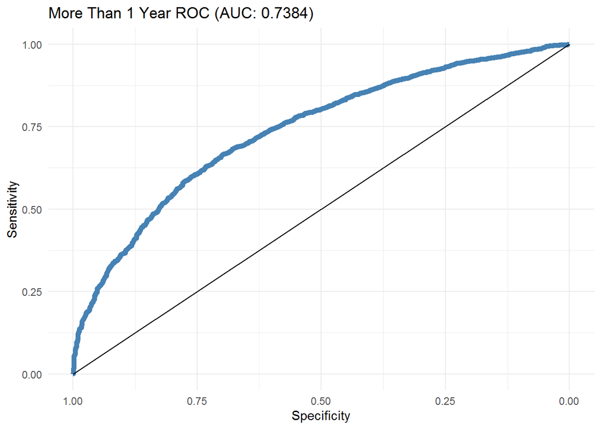

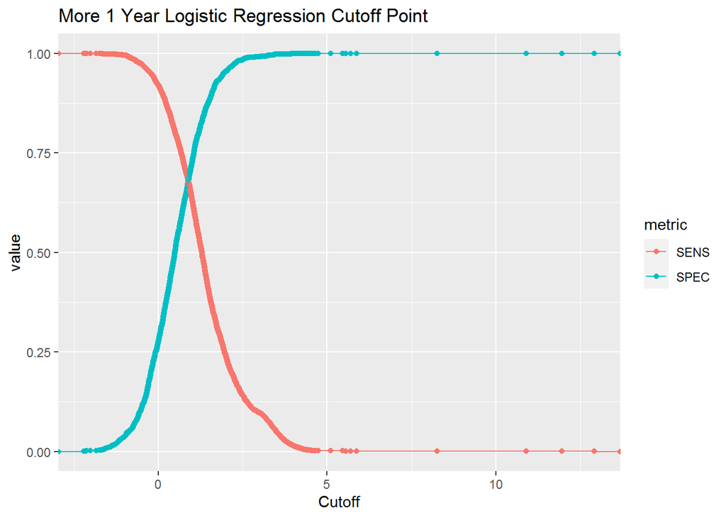

More 1 Year Optimal Cutoff Points

| Cutoff | SENS | SPEC | SUM |
| --- | --- | --- | --- |
| 0.9288 | 0.6674 | 0.6969 | 1.3643 |
| 0.9323 | 0.6657 | 0.6985 | 1.3642 |
| 0.9292 | 0.6672 | 0.6969 | 1.3641 |
| 0.9351 | 0.6651 | 0.6990 | 1.3641 |
| 0.9331 | 0.6655 | 0.6985 | 1.3640 |